# Quick Introduction to timelineR

Kenton Russell

2015-10-02

[`timelineR`](https://github.com/timelyportfolio/timelineR) lets us use the new `d3.layout.timeline` from [Elijah Meeks](http://elijahmeeks.com/) to make interactive [`d3.js`](http://d3js.org) swimlane timelines. If you prefer the more traditional `graphics` or `ggplot2` from `R`, we can also leverage `d3.layout.timeline` using [`V8`](https://github.com/jeroenooms/V8) to produce static plots.

## Installation

```r
devtools::install_github("timelyportfolio/timelineR")
```

## Examples

I very much appreciate when authors of `R` packages and JavaScript libraries provide helpful examples to demonstrate their fine work and provide a foundation for its use. This is definitely the case with Elijah Meeks and `d3.layout.timeline`. Let’s start our exploration of `timelineR` by recreating [Examples With Dates](https://gist.github.com/emeeks/280cb0607c68faf30bb5).

### Starting Point

```r
library(timelineR)

# example with dates provided by d3.layout.timeline author
#  Elijah Meeks
#  http://bl.ocks.org/emeeks/280cb0607c68faf30bb5

t1 <- timeline(
  read.csv("http://bl.ocks.org/emeeks/raw/280cb0607c68faf30bb5/wars.csv"),
  colorScale = htmlwidgets::JS(
'd3.scale.ordinal()
    .domain(["European","Native","Colonial","Latin America","Internal"])
    .range(["#96abb1", "#313746", "#b0909d", "#687a97", "#292014"])
'
  ),
  color = "sphere",
  height = "400",
  width = "80%"
)

t1
```

[interactive chart not shown]

### Add an Axis

```r
add_axis(t1)
```

[interactive chart not shown]

### Customize and Style

```r
# use this example as inspiration
#   http://jasonheppler.org/projects/war/

library(pipeR)

t1 %>>%
  add_axis(tickSize = 400) %>>%
  add_tasks(
    htmlwidgets::JS(
'
function(){
  var svg = d3.select(this.el).select("svg");
  svg.selectAll(".timeline-axis > path")
    .style("fill","none")
    .style("stroke","none");
  svg.selectAll(".timeline-axis .tick line")
    .style("stroke","gray")
    .attr("stroke-dasharray","5 5");
  svg.selectAll("rect")
    .style("stroke","white")
    .attr("rx",4);
}
'
    )
  )
```

[interactive chart not shown]

### Static Plots with ggplot2

In a feat of super-isomorphism, let’s use `d3.layout.timeline` to calculate the layout and coordinates for a `ggplot2` chart.

```r
library(ggplot2)
library(V8)

ctx <- new_context()
# get d3
ctx$source(system.file("htmlwidgets/lib/d3/d3.min.js",package="timelineR"))
```

```
## [1] "true"
```

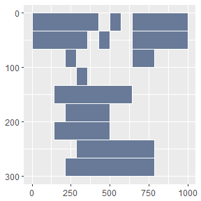

```r
# get d3.layout.timeline
ctx$source(system.file("htmlwidgets/lib/d3.layout.timeline/d3.layout.timeline.js",package="timelineR"))
# assign the simple example data to data
ctx$assign("data", read.csv("http://bl.ocks.org/emeeks/raw/d24171dac80dd535521b/int_bands.csv"))
# do the layout and get it in R
invisible(ctx$eval(
'
var timeline = d3.layout.timeline()
  .size([1000,300])
  .bandStart(function (d) {return d.s})
  .bandEnd(function (d) {return d.e})
  .dateFormat(function (d) {return parseInt(d)})

timelineBands = timeline(data);
'
))
# see if it worked
time_bands <- ctx$get("timelineBands")

library(ggplot2)
ggplot(
  time_bands,
  aes(
    xmin = start,
    ymin = y,
    xmax = end,
    ymax = y + dy
  )
) + ylim(300,0) + geom_rect(fill = "#687a97", colour = "white")
```

## Thanks

### Elijah Meeks

Elijah has made significant contribiutions to the `d3.js` community. I highly recommend his book [D3.js in Action](https://www.manning.com/books/d3-js-in-action).

### Mike Bostock

Mike Bostock has provided us an unbelievable platform to do amazing things with `d3.js`.

### Ramnath Vaidyanathan and RStudio

Ramnath Vaidyanathan and the very skilled, generous folks at RStudio have made it easy with [`htmlwidgets`](http://htmlwidgets.org) to seamlessly integrate interactive JavaScript/HTML/CSS in `R`.